# Project Overview

## Random Forest Lifetime Value Prediction Model

### Create Model

```python
# Features
features = [
    'session_duration_avg',
    'pages_per_session',
    'wishlist_items',
    'days_since_last_purchase',
    'returns_rate',
    'email_open_rate',
    'product_reviews_written',
    'social_media_engagement_score',
    'mobile_app_usage',
    'payment_method_diversity',
    'credit_balance',
    'membership_years',
    'login_frequency',
    'cart_abandonment_rate',
    'total_purchases',
    'average_order_value',
    'customer_service_calls'
]

X = df[features]
y = df['lifetime_value']

# Split
x_train, x_test, y_train, y_test = train_test_split(
    x,
    y,
    test_size=0.2,
    random_state=42
)

# Model
rf_ltv = RandomForestRegressor(
    n_estimators=200,
    max_depth=10,
    random_state=42
)

# Train
rf_ltv.fit(x_train, y_train)

# Predict
y_pred = rf_ltv.predict(x_test)

# Metrics
print("R2 Score:", r2_score(y_test, y_pred))
print("MAE:", mean_absolute_error(y_test, y_pred))
print("RMSE:", mean_squared_error(y_test, y_pred) ** 0.5)

# Add predictions back to dataframe
df['predicted_lifetime_value'] = rf_ltv.predict(X)
```

```
R2 Score: 0.9310649443508398
MAE: 162.33767788509832
RMSE: 243.37016860321646
```

### Analyze Predictions

```python
df[['lifetime_value',
   'predicted_lifetime_value']].head(20)
```

|  | lifetime_value | predicted_lifetime_value |
| --- | --- | --- |
| 0 | 953.330017 | 841.529678 |
| 1 | 1067.469971 | 1381.404028 |
| 2 | 1289.750000 | 1176.086277 |
| 3 | 2340.919922 | 2254.754395 |
| 4 | 3041.290039 | 3841.706260 |
| 5 | 1995.430054 | 2195.792517 |
| 6 | 3003.570068 | 3404.023184 |
| 7 | 1394.040039 | 1870.996289 |
| 8 | 537.210022 | 470.819067 |
| 9 | 807.840027 | 819.565517 |
| 10 | 599.409973 | 611.660057 |
| 11 | 335.920013 | 397.433297 |
| 12 | 1229.939941 | 1223.019590 |
| 13 | 1083.910034 | 1185.611458 |
| 14 | 1618.510010 | 1840.977934 |
| 15 | 1692.540039 | 1677.782732 |
| 16 | 503.260010 | 476.631725 |
| 17 | 1356.930054 | 1287.408958 |
| 18 | 1096.880005 | 1169.877093 |
| 19 | 1274.699951 | 1204.306058 |

### Feature Importance

```python
ltv_importance = pd.DataFrame({
    'Feature': x.columns,
    'Importance': rf_ltv.feature_importances_
})

ltv_importance = ltv_importance.sort_values(
    by='Importance',
    ascending=False
)

print(ltv_importance)
```

```
                          Feature  Importance
14                total_purchases    0.555523
15            average_order_value    0.421410
0            session_duration_avg    0.003259
4                    returns_rate    0.002635
1               pages_per_session    0.002363
8                mobile_app_usage    0.001972
13          cart_abandonment_rate    0.001790
5                 email_open_rate    0.001776
10                 credit_balance    0.001637
7   social_media_engagement_score    0.001431
11               membership_years    0.001299
3        days_since_last_purchase    0.001213
12                login_frequency    0.001200
2                  wishlist_items    0.000864
6         product_reviews_written    0.000645
16         customer_service_calls    0.000612
9        payment_method_diversity    0.000371
```

### Visualization Feature Importance

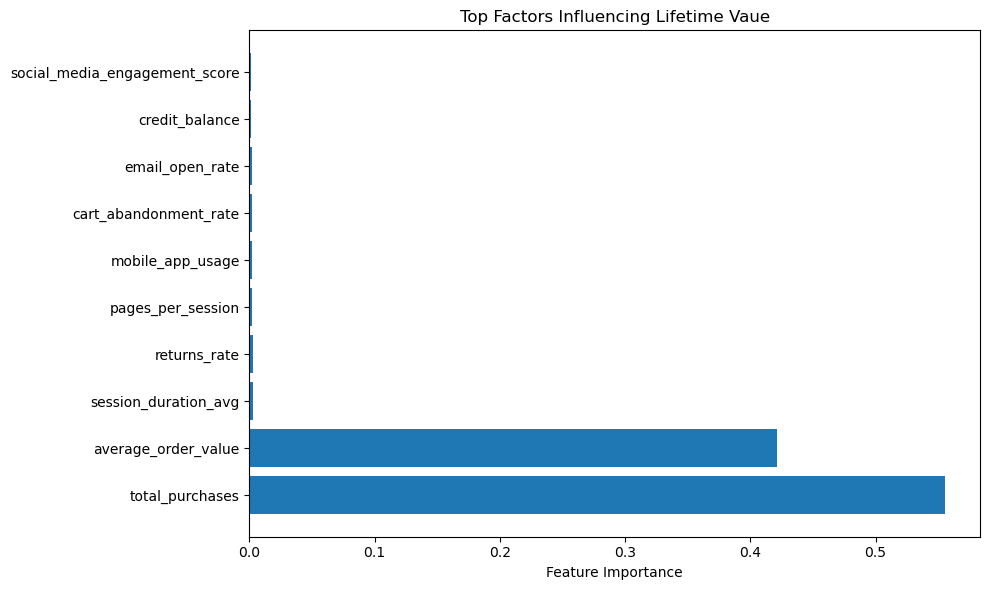

```python
top_features = ltv_importance.head(10)

plt.figure(figsize=(10,6))

plt.barh(
    top_features['Feature'],
    top_features['Importance']
)

plt.title('Top Factors Influencing Lifetime Vaue')
plt.xlabel('Feature Importance')

plt.tight_layout()
plt.show()
```

### Prepare data for clustering model

```python
df['predicted_lifetime_value'] = rf_ltv.predict(x)
df['rf_churn_probability'] = rf_model.predict_proba(x)[:,1]
```

```python
df[['predicted_lifetime_value',
    'rf_churn_probability']].head()
```

|  | predicted_lifetime_value | rf_churn_probability |
| --- | --- | --- |
| 0 | 841.529678 | 0.137157 |
| 1 | 1381.404028 | 0.274472 |
| 2 | 1176.086277 | 0.216332 |
| 3 | 2254.754395 | 0.115909 |
| 4 | 3841.706260 | 0.103958 |

## K-Means Clustering Model

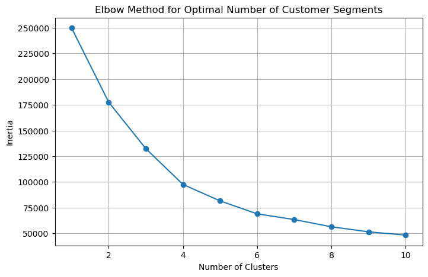

```python
# Select features for clustering
cluster_features = [
    'predicted_lifetime_value',
    'rf_churn_probability',
    'total_purchases',
    'average_order_value',
    'cart_abandonment_rate'
]

# Scale data
x_cluster = df[cluster_features]

scaler = StandardScaler()

x_scaled = scaler.fit_transform(x_cluster)

# Elbow Method
inertia = []

for k in range(1, 11):
    kmeans = KMeans(
        n_clusters=k,
        random_state=42,
        n_init=10
    )

    kmeans.fit(x_scaled)

    inertia.append(kmeans.inertia_)

# Plot Elbow Curve
plt.figure(figsize=(8,5))

plt.plot(
    range(1,11),
    inertia,
    marker='o'
)

plt.title('Elbow Method for Optimal Number of Customer Segments')
plt.xlabel('Number of Clusters')
plt.ylabel('Inertia')

plt.grid(True)

plt.show()
```

### Creating the segments

```python
# Create K-Means model
kmeans = KMeans(
    n_clusters=4,
    random_state=42,
    n_init=10
)

# Fit and assign clsuters
df['customer_segment'] = kmeans.fit_predict(x_scaled)

# Check segment sizes
print(df['customer_segment'].value_counts().sort_index())
```

```
customer_segment
0    13365
1     9478
2    27092
3       25
Name: count, dtype: int64
```

### Visualize the clusters

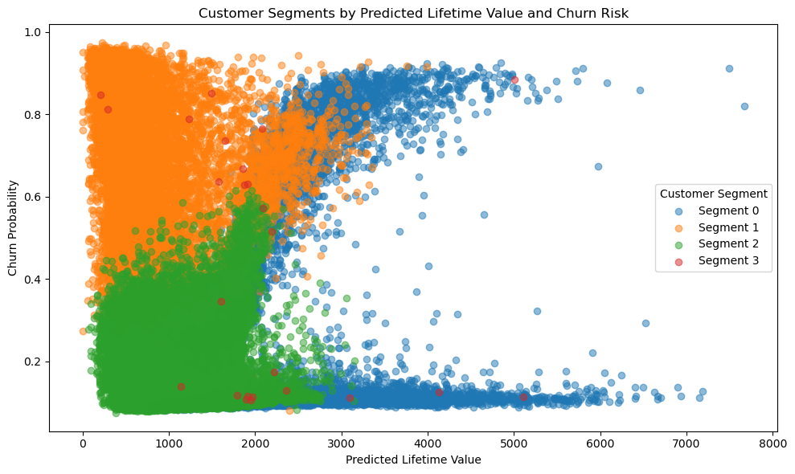

```python
plt.figure(figsize=(10,6))

for segment in sorted(df['customer_segment'].unique()):
    segment_data = df[df['customer_segment'] == segment]

    plt.scatter(
        segment_data['predicted_lifetime_value'],
        segment_data['rf_churn_probability'],
        label=f'Segment {segment}',
        alpha=0.5
    )

plt.title('Customer Segments by Predicted Lifetime Value and Churn Risk')
plt.xlabel('Predicted Lifetime Value')
plt.ylabel('Churn Probability')
plt.legend(title='Customer Segment')
plt.tight_layout()
plt.show()
```

### Analyze customer segments

```python
segment_profile = df.groupby('customer_segment')[[
    'predicted_lifetime_value',
    'rf_churn_probability',
    'total_purchases',
    'average_order_value',
    'cart_abandonment_rate'
]].mean().round(2)

print(segment_profile)
```

```
                  predicted_lifetime_value  rf_churn_probability  \
customer_segment
0                                  2457.24                  0.25
1                                   871.86                  0.67
2                                  1136.46                  0.18
3                                  2105.98                  0.44

                  total_purchases  average_order_value  cart_abandonment_rate
customer_segment
0                           20.93               135.24                  40.26
1                            7.16               126.26                  76.15
2                           11.36               109.13                  58.72
3                           14.40              7593.42                  54.66
```

### Naming the clusters

```python
segment_mapping = {
    0: 'VIP Customers',
    1: 'At-Risk Customers',
    2: 'Core Customer Base',
    3: 'High-Spend Outliers'
}

df['segment_name'] = df['customer_segment'].map(segment_mapping)
```

## Key Insights

### Cart Abandonment Is a Strong Indicator of Customer Risk

- Customers with higher cart abandonment rates generated significantly lower lifetime value.
- Cart abandonment showed one of the strongest relationships with both churn and customer value.
- The churn prediction model identified cart abandonment rate as the most important factor influencing churn risk.

### Customer Service Calls May Signal Customer Dissatisfaction

- Customers who contacted customer service more frequently tended to have lower lifetime value.
- Customer service calls were one of the strongest predictors of churn in the machine learning model.
- Increased support activity may indicate unresolved issues that could lead to customer loss.

### Purchasing Behavior Is the Primary Driver of Lifetime Value

- Customers who made more purchases and spent more per order consistently generated greater lifetime value.
- Total purchases and average order value were the most important variables in the lifetime value prediction model.
- Purchase frequency and spending habits were the strongest indicators of long-term customer value.

### Combining Multiple Analyses Created a More Complete Customer View

```python
df.to_csv(
    'ecommerce_tableau.csv',
    index=False
)
```